# RNA-seq data cleaning

Uganda: TB-induced RSTR vs LTBI

Kim Dill-McFarland, kadm@uw.edu

version March 03, 2021

# Background

The purpose of this workflow is to complete basic data cleaning of metadata and RNA-seq libraries. This includes 1) removing low coverage libraries, 2) filtering rare genes, 3) removing outlying libraries and duplicates, and 4) normalizing for RNA composition.

# Setup

Load packages

```r
# Empirical analysis of digital gene expression data
## Data normalization
library(edgeR)

# Data manipulation and figures
library(tidyverse)
  # Modify ggplot figures to non-overlapping text labels
  library(ggrepel)
  # Modify ggplot data order within facets
  library(drlib)
  # Plot log scales
  library(scales)
  #Multi-panel figures
  library(cowplot)

# Batch correction
library(scBatch) #https://github.com/tengfei-emory/scBatch
library(sva) #https://github.com/zhangyuqing/ComBat-seq

# Print pretty table to knit file
library(knitr)
library(kableExtra)
  options(knitr.kable.NA = '')
  opts_chunk$set(fig.pos = 'H')

#Create 'not in' operator
`%notin%` <- Negate(`%in%`)
```

Set seed

```r
set.seed(4389)
```

# Read in and format data

## Metadata

```r
meta <- read_csv("data_raw/2020.11.20RSTR_Hawn_metadata.csv")
```

## Counts

```r
#Orig data set
count1 <- read_csv("data_raw/Hawn_UgandaMacrophage_counts.csv") %>%
  rename(symbol = X1)
#Validation data set
count2 <- read_csv("data_raw/Hawn_UgandaValidation_counts.csv") %>%
  rename(symbol = X1) %>%
  #rename to match count1
  rename_all(~gsub("-", "_", .)) %>%
  rename_all(~gsub("Media", "MEDIA", .))
```

Remove samples from the original data set that failed (*e.g.* HIV+ or contamination)

# Data cleaning: combined

Combine original and validation data sets. Create metadata variable for original vs validation data sets.

```r
count.all <- full_join(count1.filter, count2, by="symbol")
```

```r
meta.all <- data.frame(libID = colnames(count.all)[-1]) %>%
  separate(libID, into=c("RSID", "condition"),
           sep="_", remove = FALSE) %>%
  mutate(condition = gsub(".[x|y]", "", condition)) %>%
  left_join(meta, by=c("RSID"="RS_SUB_ACCESSION_NO")) %>%
  arrange(libID) %>%
  #orig vs validation
  mutate(experiment = ifelse(grepl(".x", libID), "original",
                             ifelse(grepl(".y", libID), "validation",
           ifelse(libID %in% c("RS102076_MEDIA","RS102076_TB",
                                          "RS102111_TB"), "original",
                             ifelse(libID %in% c("RS102111_MEDIA"),
                                    "validation",
                                    ifelse(libID %in% colnames(count1.filter),
                                           "original",
                                           ifelse(libID %in% colnames(count2),
                                                  "validation", NA)))))))
```

```r
#Reorder count columns
count.all <- count.all %>%
  dplyr::select(symbol, meta.all$libID)

#Check
identical(colnames(count.all)[-1], meta.all$libID)
```

```
## [1] TRUE
```

## Filter protein coding genes

Load key and format for all possible symbols.

Filter gene key to protein coding (pc) genes that occur in the count data set.

Filter the count data to pc genes as well.

#### Check genes

All genes in count and key in the same order?

```
## [1] TRUE
```

## Assess library coverage

#### Total aligned counts

Assess aligned counts per library. Higher counts indicate high coverage and are preferred.

Plot total counts per library. Libraries outside cutoffs are labeled as “questionable”. The minimum total sequences cutoff set above is indicated by a horizontal line.

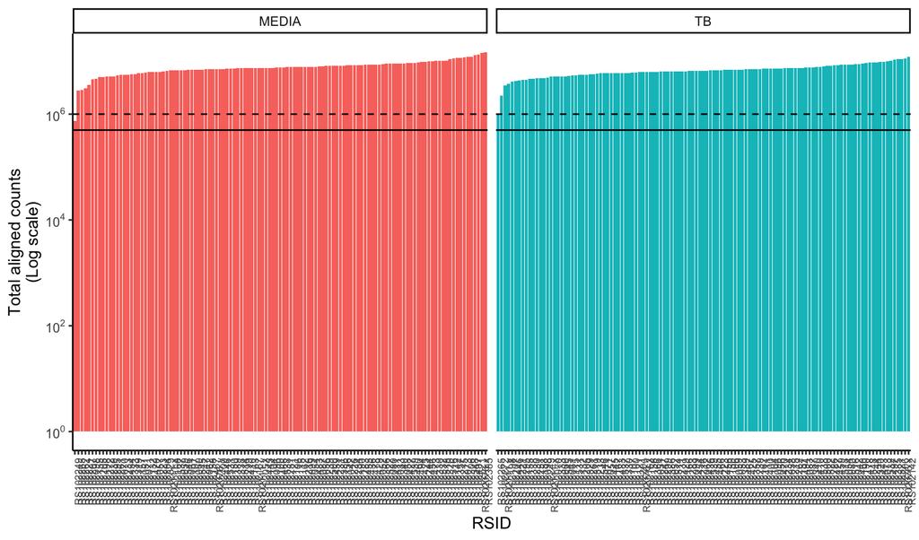

## Filter by library coverage

All libraries have sufficient sequences for analysis.

## Correct batch effects

There is an apparent batch effect between the original and validation data sets. This is likely caused by true batch differences including about 1 year between processing and sequencing on a HiSeq vs NovaSeq.

First, we explore quantile normalization with `scBatch`.

```r
#Calculate distances
scbatch.dist <- QuantNorm(count.all.pc.mat,
            logdat = FALSE, standardize = FALSE,
            batch = as.numeric(as.factor(meta.all$experiment)),
            method = "row/column", cor_method = "pearson",
            tol = 1E-4, max = 50)

#correct counts
## Param from bulk RNA-seq example
## https://github.com/tengfei-emory/scBatch-paper-scripts/blob/master/Fig3_ENCODE_script.r
count.all.pc.scbatch <- scBatchCpp(c = count.all.pc.mat,
             w = diag(ncol(count.all.pc)-1),
             d = scbatch.dist,
             m = 2, max = 50, step = 1E-6, tol = 1E-20,
             derif = scBatch::derif,
             verbose = TRUE)
```

Next, we explore negative binomial normalization with `ComBat-Seq` including Mtb condition, RSTR status, sex, and age as co-variates.

```r
count.all.pc.combat <- ComBat_seq(count.all.pc.mat,
                 batch = meta.all$experiment,
                 group = meta.all$condition,
                 covar_mod = meta.all[,c("Sample_Group","M0_KCVSEX",
                                           "KCHCA_AGE_YR_CURRENT")])

save(count.all.pc.combat, file="data_raw/combatSeq.counts.RData")
```

Comparing these methods, we see that `Combat-Seq` better corrects for batch effects. It also runs signficantly faster than `scBatch` and allows additional co-variate modeling. Thus, `Combat-Seq` will be used.

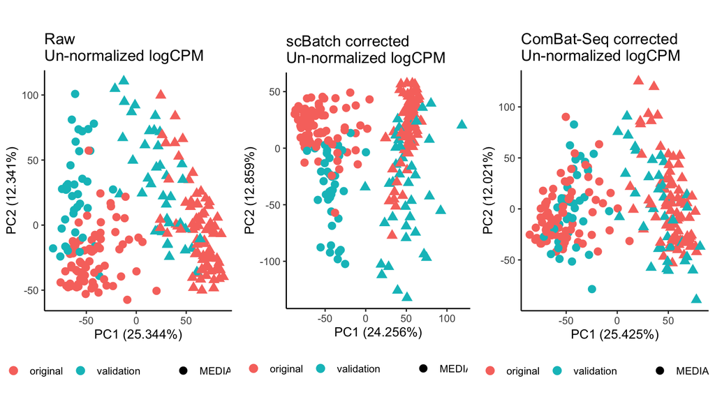

## PCA outliers

Visualize PCA outliers defined as any library with PC1 and/or PC2 values greater than 3 standard deviations away from the PC mean of their respective condition group.

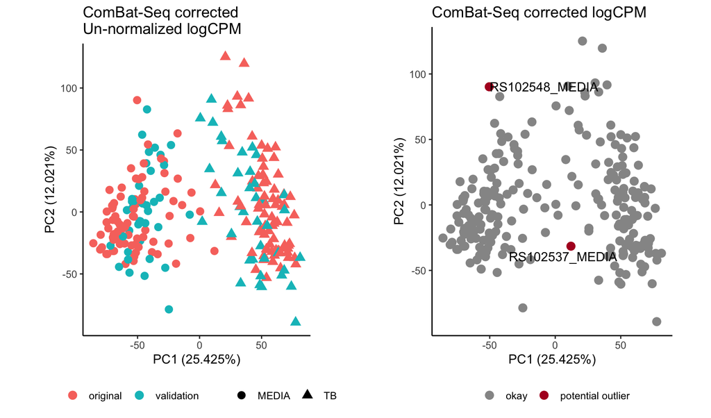

## Filter PCA outliers

While some libraries were flagged as potential outliers, they cluster with their respective groups overall. Thus, these samples will not be removed and will be re-assessed after rare gene filtering.

## Duplicate samples

#### Assess duplicates

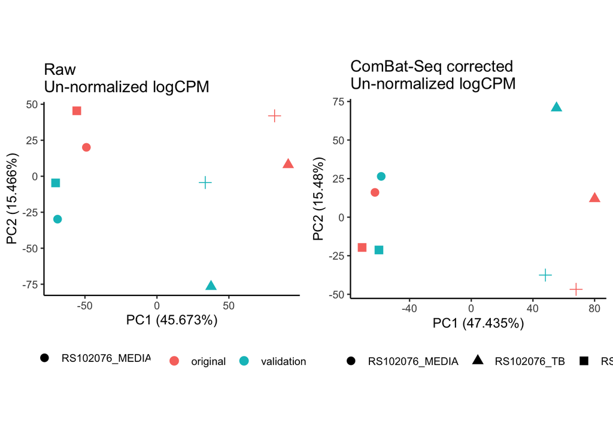

Total sequences per sample.

[output not shown]

## Filter duplicates

Keep duplicates with the most sequences.

Keep data for samples with remaining RNA-seq data.

### Summarize samples

All samples in count and metadata in the same order?

```
## [1] TRUE
```

Total libraries

| Sample_Group | condition | n |
| --- | --- | --- |
| LTBI | MEDIA | 57 |
| LTBI | TB | 57 |
| RSTR | MEDIA | 58 |
| RSTR | TB | 58 |

## Filter rare genes

Create DGEList object.

The raw gene sets contain highly variable, low abundance/rare genes (left side of plots). These genes will be filtered at 1 CPM in at least 5% of samples (N = 12).

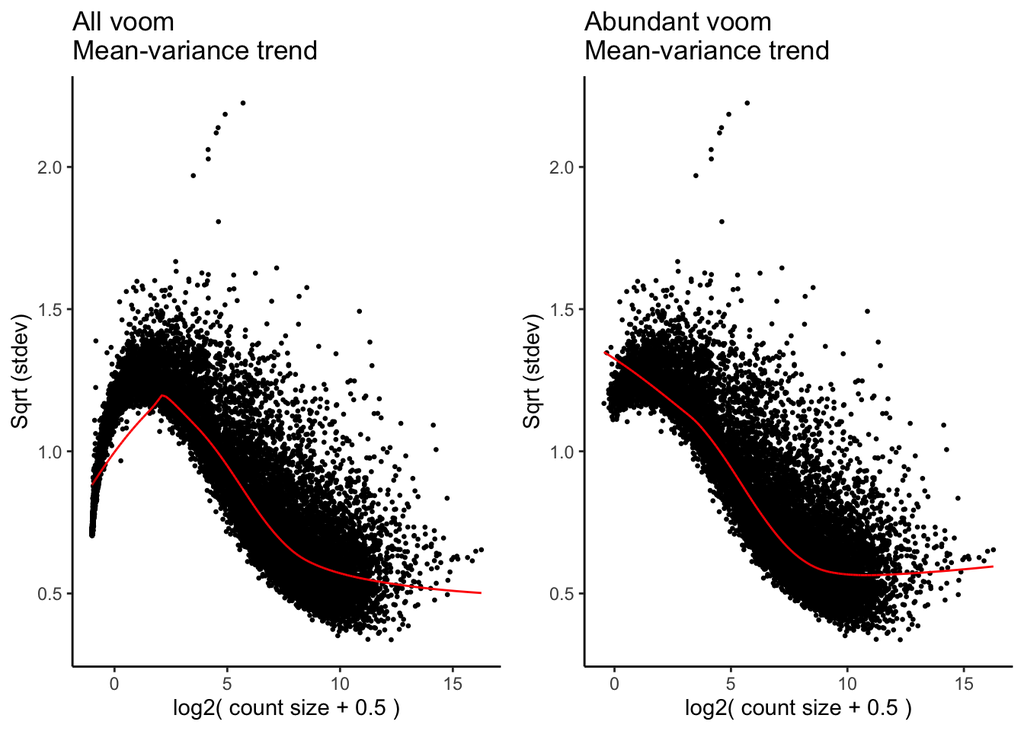

```r
source("https://raw.githubusercontent.com/kdillmcfarland/R_bioinformatic_scripts/master/RNAseq_rare_gene_filter.R")

rare.gene.filter(dat = dat, names = "symbol",
                 min.pct = 5,
                 min.CPM = 1,
                 name = 'dat.abund')
```

This removes 5058 (~ 27%) genes.

## Normalize for RNA composition

Calculate factors to scale library sizes.

```r
dat.abund.norm <- calcNormFactors(dat.abund)
```

## Normalize with voom

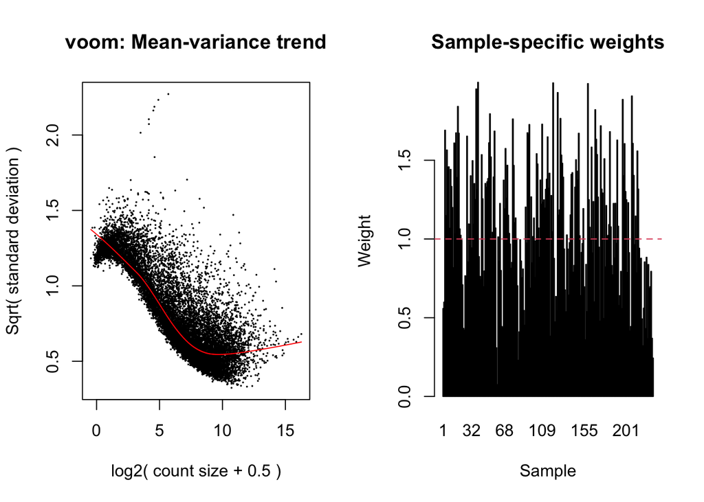

```r
dat.abund.norm.voom <- voomWithQualityWeights(
                           dat.abund.norm,
                           design=model.matrix(~ condition,
                                 data=dat.abund.norm$samples),
                           plot=TRUE)
```

## PCA clean data

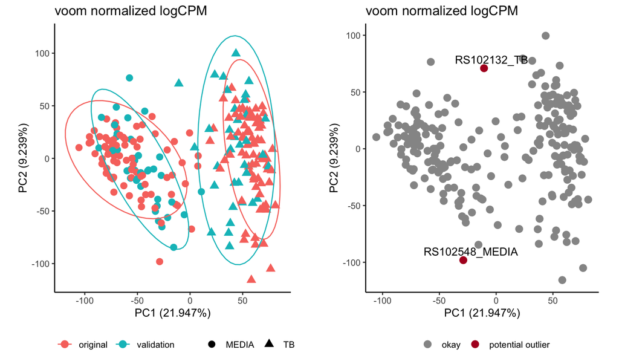

## Save combined data

Write as RData

```r
#Rename to short form
dat.combined <- dat.abund.norm
dat.combined.voom <- dat.abund.norm.voom
meta.combined <- meta.dedup

save(dat.combined, dat.combined.voom, meta.combined,
     file="data_clean/RSTR_RNAseq_data_combined_clean.RData")
```

## Remove FULLIDNO duplicates

Duplicate samples were removed by matching RSIDs. However, some individuals (FULLIDNO) have multiple samples in the data set. For these, the higher quality sample will be retained.

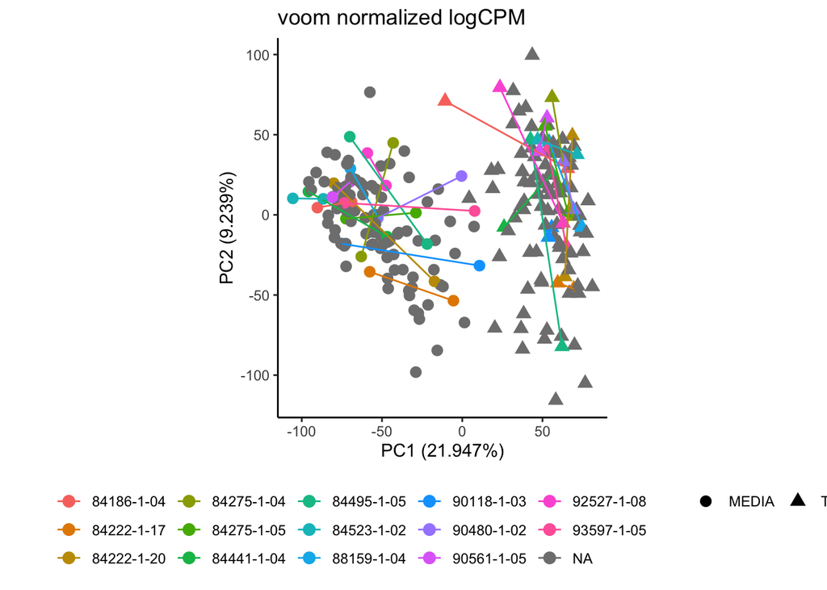

```r
# list RSID with the most media sequences per FULLIDNO donor
to.keep <- dat.abund.norm$samples %>%
  #media samples
  filter(condition == "MEDIA") %>%
  #Keep library with most sequences
  group_by(FULLIDNO) %>%
  slice_max(lib.size) %>%
  ungroup() %>%
  select(RSID) %>% unlist(use.names = FALSE)

###
dat.abund.norm.dedup <- dat.abund.norm

dat.abund.norm.dedup$samples <- dat.abund.norm.dedup$samples %>%
  filter(RSID %in% to.keep)

dat.abund.norm.dedup$counts <- dat.abund.norm.dedup$counts %>%
  rownames_to_column() %>%
  select(rowname, all_of(dat.abund.norm.dedup$samples$libID)) %>%
  column_to_rownames()

####
dat.abund.norm.voom.dedup <- dat.abund.norm.voom

dat.abund.norm.voom.dedup$targets <- dat.abund.norm.voom.dedup$targets %>%
  filter(RSID %in% to.keep)

dat.abund.norm.voom.dedup$E <- as.data.frame(dat.abund.norm.voom.dedup$E) %>%
  rownames_to_column() %>%
  select(rowname, all_of(dat.abund.norm.voom.dedup$targets$libID)) %>%
  column_to_rownames()

####
meta.dedup2 <- meta.dedup %>%
  filter(RSID %in% to.keep)
```

This removed 28 samples.

```r
#Rename to short form
dat.combined <- dat.abund.norm.dedup
dat.combined.voom <- dat.abund.norm.voom.dedup
meta.combined <- meta.dedup2

save(dat.combined, dat.combined.voom, meta.combined,
     file="data_clean/RSTR_RNAseq_data_combined_uniqueFULLID.RData")
```